# Assignment 5

1. The heart function is the scalar function $F=(x^2+\frac{9}{4}y^2+z^2-1)^3-x^2 z^3-\frac{9}{80}y^2 z^3$. When $F=0$, the function describes a heart shape surface in the 3D space. In this excercise, you will use this function to plot a 3D heart using the module called `measure`, and the 3D plot techniques you have learnt in the lecture.  
   The code below creates the plotting data for `plot_trisurf(X,Y,faces,Z)` with `X=verts[:,0]`, `Y=verts[:,1]`, `Z=verts[:,2]`. The faces parameter is optional for trisurf, but it makes the figure look better by choosing the triangular surfaces created by the `measure.marching_cubes_lewiner` function.  
   Hint: Marching cubes is a simple algorithm for creating a triangle mesh from an implicit function (one of the form $f(x, y, z) = 0$). Since the marching_cubes function only takes in the value of $F$ but not $x, y, z$, the resultant points all range from 0 to the number of total points in the corresponding direction times the spacing among the points (6/100 in the following code), so you will need to shift the data to make it centered around 0.

```python
# Do not modify this cell

import numpy as np
from skimage import measure

# Define the heart function
def F(x,y,z):
    return (x**2 + 9*y**2/4 + z**2-1)**3 - x**2 * z**3 - 9*y**2 * z**3/80

# Set up mesh
n = 100

x = np.linspace(-3,3,n)
y = np.linspace(-3,3,n)
z = np.linspace(-3,3,n)
X, Y, Z =  np.meshgrid(x, y, z, indexing='ij')

vol = F(X,Y,Z)

# Extract a 2D surface mesh from a 3D volume (F=0)
verts, faces, _, _ = measure.marching_cubes_lewiner(vol, 0, spacing=(6/n, 6/n, 6/n))
```

For this problem, you will create a 3D figure of the size 8 by 8. Plot the data obtained in the previous cell using `ax.plot_trisurf(X,Y,faces,Z)`. Modify the `plot_trisurf` to use color map `'Spectral'`. Try to shift the heart surface so that it is centered at the origin. Set the title to be "Love from XXX" with XXX being your name. Set the view angle to be (15, -70).  
As the last step of this problem, draw the cross-section of the 3D heart intersecting with the $y=0$ plane on the right-hand-side wall of the same figure using `contour3D` with the parameter `zdir='y'` and `levels=0` in red color. To make the projection visible, set the opacity of the 3D heart to `alpha=0.8`.  
Your output should look like this:

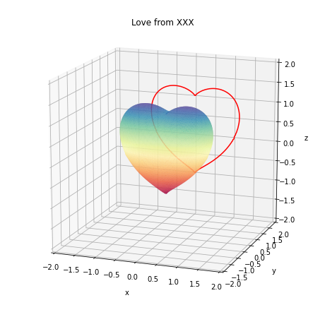

```python
ZZ.shape
```

```
(4644,)
```

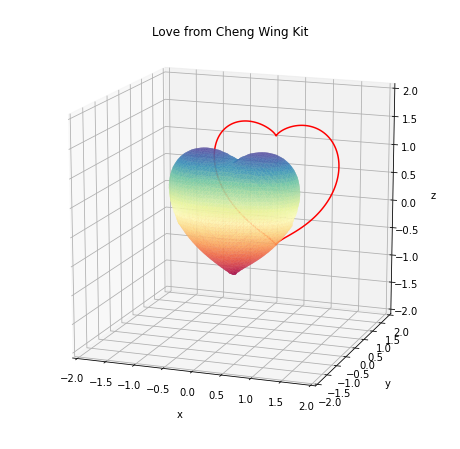

```python
# Q1 Code
import matplotlib.pyplot as plt
from mpl_toolkits import mplot3d
fig = plt.figure(figsize=(8,8))
ax = plt.axes(projection='3d')

# 3D heart
XX = verts[:,0]-3
YY = verts[:,1]-3
ZZ = verts[:,2]-3
ax.plot_trisurf(XX,YY,faces,ZZ,cmap='Spectral',alpha=0.8)

# heart contour
X, Z = np.meshgrid(np.linspace(-3,3,n*10), np.linspace(-3,3,n*10))
Y=np.zeros(X.shape)
F0=F(X, Y, Z)
ax.contour3D(X, F0, Z, levels=[0],zdir='y',colors='r', offset=2)

# plot control
ax.set_xlim(-2,2)
ax.set_ylim(-2,2)
ax.set_zlim(-2,2)
ax.set_xlabel('x',labelpad=10)
ax.set_ylabel('y',labelpad=10)
ax.set_zlabel('z',labelpad=10)
ax.set_title('Love from Cheng Wing Kit')
ax.view_init(15,-70)
```

1. Make the following video. The converging point should rotate 1 complete circle in 100 time steps or frames. Display the animation by `matplotlib.animation.FuncAnimation` and `%matplotlib notebook`, and also save it as "sin_cos_movie" in both gif and mp4 formats. Your output should look like this:

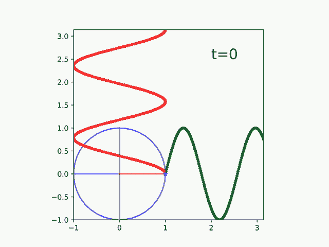

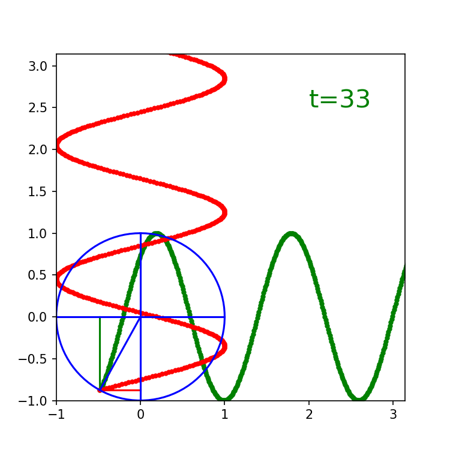

```python
# Q2 Code
%matplotlib notebook
import numpy as np
import matplotlib.pyplot as plt
from matplotlib.animation import FuncAnimation
fig, ax = plt.subplots(figsize=(5,5))

#prepare something you want to update
ln1, = plt.plot ([],[],'g.')
ln2, = plt.plot ([],[],'g-')
ln3, = plt.plot ([],[],'r.')
ln4, = plt.plot ([],[],'r-')
ln5, = plt.plot ([],[],'b-')

text_step = plt.text(2,2.5,'t=',color ='g',fontsize = 20)
#the initializaion function
def init():
    ax.set_xlim(-1,np.pi)
    ax.set_ylim(-1,np.pi)
    ax.set_xticks(np.linspace(-1,3,5))
    return ln1,ln2,ln3,ln4,ln5,text_step

def updates(t):
    # set straight lines
    dtheta = 2*np.pi/100
    xm = np.cos(dtheta*t)
    ym = -np.sin(dtheta*t)
    ln2.set_data([xm,xm],[0,ym])
    ln4.set_data([0,xm],[ym,ym])
    ln5.set_data([0,xm],[0,ym])

    # set curve lines
    xc = np.linspace(xm,2*np.pi,700)
    yc = -(50>=t)*np.sin((xc-xc[0])*np.pi*1.25+t/50*np.pi)+(50<t)*np.sin(-(xc-xc[0])*np.pi*1.25-t/50*np.pi)
    ln1.set_data(xc,yc)
    yc1 = np.linspace(ym,2*np.pi,700)
    xc1 = (50>=t)*np.cos(-(yc1-yc1[0])*np.pi*1.25+t/50*np.pi)+(50<t)*np.cos((yc1-yc1[0])*np.pi*1.25-t/50*np.pi)
    ln3.set_data(xc1,yc1)
    text_step.set_text('t='+str(t))
    return ln1,ln2,ln3,ln4,ln5,text_step

# plot static circle and lines
theta = np.linspace(0,2*np.pi,100)
r = 1
xc = r*np.sin(theta)
yc = r*np.cos(theta)
plt.plot(xc,yc,c='b')
plt.plot(np.zeros(100),np.linspace(-1,1,100),c='b')
plt.plot(np.linspace(-1,1,100),np.zeros(100),c='b')

# plot lines animation
ani = FuncAnimation(fig=fig,
                    init_func=init,
                    func=updates,
                    frames=100,
                    interval=100,
                    blit=True)
```